# Rcode: COMPSAC 2024

Sulalitha Bowala

```r
rm(list=ls(all=TRUE)) # Remove objects from environment
set.seed(12)
```

```r
### Call packages
require("tseries") # load the tseries library
require("zoo")
require("moments")
require("car")
require("MASS")
require("stats")
require("VGAM")
require("fGarch")
require("quantmod") # To download data alternatively
```

```r
require("PerformanceAnalytics") # To draw Timeseries graphs
require("scales")
require("PEIP")
require("dplyr")
require("lubridate")
require("tidyverse")
require("gridExtra")
require("gdata")
require("xtable")
require("vioplot")
require("fpp3")
require("readr")
require("tis")
require("tibble")
require("tsibble")
require("stringr")
require("magrittr")
require("fable")
require("Metrics") # rmse()
require("forecast")
## Import data
## Ontario data

Ontario_demand_hourly <- read.csv("Data_2018_2019.csv")
```

```r
### Manipulate hourly data to obtain daily data
### + create a new categorical variable (day-type)

Ontario_demand_hourly$Time <- as.POSIXct(Ontario_demand_hourly$Time, "%Y-%m-%d %H:%M:%S")
```

```r
Ontario_demand_hourly$Temperature <- Ontario_demand_hourly$Temperature
Ontario_demand_hourly$Precipitation <- Ontario_demand_hourly$Precipitation
Ontario_demand_hourly$CloudCover <- Ontario_demand_hourly$CloudCover
Ontario_demand_hourly$IrradianceSurface <- Ontario_demand_hourly$IrradianceSurface
Ontario_demand_hourly$IrradianceToa <- Ontario_demand_hourly$IrradianceToa
Ontario_demand_hourly$Snowfall <- Ontario_demand_hourly$Snowfall
Ontario_demand_hourly$SnowMass <- Ontario_demand_hourly$SnowMass
Ontario_demand_hourly$Location <- Ontario_demand_hourly$Location
Ontario_demand_hourly <- as_tsibble(Ontario_demand_hourly,index = 'Time',key = 'Location')

Ontario_demand_hourly <- Ontario_demand_hourly %>%
  mutate(
    Date = date( Time)
  )
Ontario_demand_hourly <- Ontario_demand_hourly %>%
  mutate(
    Holiday = isHoliday(Ontario_demand_hourly$Date)
  )
Ontario_demand_hourly <- Ontario_demand_hourly %>%
 mutate(Day_Type = case_when(
    Holiday ~ "Holiday",
    wday(Date) %in% 2:6 ~ "Weekday",
    TRUE ~ "Weekend"
  ))
#
head(Ontario_demand_hourly)
```

```
## # A tsibble: 6 x 14 [1h] <%Y-%m-%d %H:%M:%S>
## # Key:       Location [6]
##   Time                Precipitation Temperature IrradianceSurface IrradianceToa
##   <dttm>                      <dbl>       <dbl>             <dbl>         <dbl>
## 1 2018-01-01 00:00:00        0.0099       -16.7                 0             0
## 2 2018-01-01 01:00:00        0.0112       -17.0                 0             0
## 3 2018-01-01 02:00:00        0.0113       -17.2                 0             0
## 4 2018-01-01 03:00:00        0.0125       -17.5                 0             0
## 5 2018-01-01 04:00:00        0.0156       -17.7                 0             0
## 6 2018-01-01 05:00:00        0.0191       -17.7                 0             0
## # ℹ 9 more variables: Snowfall <dbl>, SnowMass <dbl>, CloudCover <dbl>,
## #   AirDensity <dbl>, Demand <int>, Location <int>, Date <date>, Holiday <lgl>,
## #   Day_Type <chr>
```

```r
tail(Ontario_demand_hourly)
```

```
## # A tsibble: 6 x 14 [1h] <%Y-%m-%d %H:%M:%S>
## # Key:       Location [6]
##   Time                Precipitation Temperature IrradianceSurface IrradianceToa
##   <dttm>                      <dbl>       <dbl>             <dbl>         <dbl>
## 1 2019-12-31 18:00:00        0.229       -0.519           99.3         497.
## 2 2019-12-31 19:00:00        0.172       -0.6             74.7         394.
## 3 2019-12-31 20:00:00        0.143       -0.73            45.3         237.
## 4 2019-12-31 21:00:00        0.123       -0.999            9.47         52.2
## 5 2019-12-31 22:00:00        0.0986      -1.26             0.0079        0.0352
## 6 2019-12-31 23:00:00        0.0625      -1.48             0             0
## # ℹ 9 more variables: Snowfall <dbl>, SnowMass <dbl>, CloudCover <dbl>,
## #   AirDensity <dbl>, Demand <int>, Location <int>, Date <date>, Holiday <lgl>,
## #   Day_Type <chr>
```

```r
## Rename columns

Ontario_demand_hourly<-Ontario_demand_hourly[,c("Time","Precipitation","Temperature","IrradianceSurface","IrradianceToa","Snowfall","SnowMass","CloudCover","AirDensity","Demand","Location","Date","Holiday","Day_Type")]
```

```r
## Daily data

# Ontario data
Ontario.Daily <- Ontario_demand_hourly %>%

  index_by(Date = date(Time)) %>%
  summarise(
    Demand = mean(Demand),
    Temperature = mean(Temperature),
    Holiday = any(Holiday),
    Precipitation = mean(Precipitation),
    IrradianceSurface = mean(IrradianceSurface),
    IrradianceToa = mean(IrradianceToa),
    Snowfall = mean(Snowfall),
    SnowMass = mean(SnowMass),
    CloudCover = mean(CloudCover),
    AirDensity = mean(AirDensity),
  ) %>%
  mutate(Day_Type = case_when(
    Holiday ~ "Holiday",
    wday(Date) %in% 2:6 ~ "Weekday",
    TRUE ~ "Weekend"
  ))
Ontario.Daily <- Ontario.Daily %>%
  mutate(Temperature2 = Temperature^2,
         HolidayNew = if_else(Holiday == "TRUE", 1, 0),
         Day_TypeNew = if_else(Day_Type == "Weekday", 1, 0))

head(Ontario.Daily)
```

```
## # A tsibble: 6 x 15 [1D]
##   Date       Demand Temperature Holiday Precipitation IrradianceSurface
##   <date>      <dbl>       <dbl> <lgl>           <dbl>             <dbl>
## 1 2018-01-01 16931.       -14.9 TRUE           0.0216              52.0
## 2 2018-01-02 17953.       -11.4 FALSE          0.0244              41.9
## 3 2018-01-03 18123.       -10.3 FALSE          0.0231              48.7
## 4 2018-01-04 18050.       -11.2 FALSE          0.0263              56.7
## 5 2018-01-05 18961.       -17.6 FALSE          0.0532              42.2
## 6 2018-01-06 18514.       -18.5 FALSE          0.0181              47.7
## # ℹ 9 more variables: IrradianceToa <dbl>, Snowfall <dbl>, SnowMass <dbl>,
## #   CloudCover <dbl>, AirDensity <dbl>, Day_Type <chr>, Temperature2 <dbl>,
## #   HolidayNew <dbl>, Day_TypeNew <dbl>
```

```r
tail(Ontario.Daily)
```

```
## # A tsibble: 6 x 15 [1D]
##   Date       Demand Temperature Holiday Precipitation IrradianceSurface
##   <date>      <dbl>       <dbl> <lgl>           <dbl>             <dbl>
## 1 2019-12-26 14145.      0.462  FALSE         0.0152               22.7
## 2 2019-12-27 14385.      4.19   FALSE         0.0257               65.4
## 3 2019-12-28 14316.      0.0134 FALSE         0.00906              80.0
## 4 2019-12-29 14671.     -0.148  FALSE         0.156                16.9
## 5 2019-12-30 15018.      1.87   FALSE         0.307                59.6
## 6 2019-12-31 14699      -0.362  FALSE         0.183                24.1
## # ℹ 9 more variables: IrradianceToa <dbl>, Snowfall <dbl>, SnowMass <dbl>,
## #   CloudCover <dbl>, AirDensity <dbl>, Day_Type <chr>, Temperature2 <dbl>,
## #   HolidayNew <dbl>, Day_TypeNew <dbl>
```

whether data: https://www.renewables.ninja/

We believe Temperature is affected by other covariates (Precipitation, IrradianceSurface, IrradianceToa, Snowfall, SnowMass, CloudCover, AirDensity) available in the data.

Description of covariates:

Air temperature (°C): Air temperature at 2 meters above ground. T2M variable in MERRA-2, converted from K.

Precipitation (mm / hour): Total bias-corrected precipitation, over land only. PRECTOTLAND variable in MERRA-2, converted from kg m⁻² s⁻¹

Snowfall (mm / hour): Total bias-corrected precipitation in the form of snow, over land only. PRECSNOLAND variable in MERRA-2, converted from kg m⁻² s⁻¹

Snow mass (kg / m²): Amount of snow per land area. SNOMAS variable in MERRA-2, in native units.

Air density (kg / m³): Air density at ground level. RHOA variable in MERRA-2, in native units.

Ground-level solar irradiance (W / m²): Surface-level incident shortwave radiation flux, considering cloud cover and aerosols. SWGDN variable in MERRA-2, in native units. Note, MERRA-2 uses the mean annual climate for aerosols, rather than time-varying quantity.

Top of atmosphere solar irradiance (W / m²): Top of atmosphere incident shortwave radiation flux, before cloud cover and aerosol influences. SWTDN variable in MERRA-2, in native units.

Cloud cover fraction: Fraction of cloud cover, averaged over grid cell and summed over all height above ground. CLDTOT variable in MERRA-2, in native units (a [0, 1] scale).

Check for multicollinearity among selected variables (Precipitation, IrradianceSurface, IrradianceToa, Snowfall, SnowMass, CloudCover, AirDensity).

```r
## VIF (Variance Inflation Factor)

library(car)

model.VIF <- lm(Temperature ~ Precipitation + IrradianceSurface + IrradianceToa + Snowfall + SnowMass + CloudCover + AirDensity, data = Ontario.Daily)

summary(model.VIF)
```

```
##
## Call:
## lm(formula = Temperature ~ Precipitation + IrradianceSurface +
##     IrradianceToa + Snowfall + SnowMass + CloudCover + AirDensity,
##     data = Ontario.Daily)
##
## Residuals:
##     Min      1Q  Median      3Q     Max
## -4.9807 -1.1396 -0.0165  1.1656  4.1187
##
## Coefficients:
##                     Estimate Std. Error t value Pr(>|t|)
## (Intercept)        2.378e+02  2.756e+00  86.309  < 2e-16 ***
## Precipitation     -3.067e+00  7.219e-01  -4.248 2.43e-05 ***
## IrradianceSurface  5.755e-03  2.105e-03   2.734 0.006406 **
## IrradianceToa      1.175e-03  1.410e-03   0.834 0.404721
## Snowfall          -3.654e+00  1.695e+00  -2.156 0.031444 *
## SnowMass          -5.288e-02  1.555e-02  -3.402 0.000707 ***
## CloudCover        -7.400e-01  4.284e-01  -1.727 0.084540 .
## AirDensity        -1.878e+02  2.137e+00 -87.897  < 2e-16 ***
## ---
## Signif. codes:  0 '***' 0.001 '**' 0.01 '*' 0.05 '.' 0.1 ' ' 1
##
## Residual standard error: 1.647 on 722 degrees of freedom
## Multiple R-squared:  0.978,  Adjusted R-squared:  0.9778
## F-statistic:  4588 on 7 and 722 DF,  p-value: < 2.2e-16
```

```r
# Calculate VIF for selected variables
vif_values <- vif(model.VIF)

# Print VIF values
print(vif_values)
```

```
##     Precipitation IrradianceSurface     IrradianceToa          Snowfall
##          1.887588         10.637492          8.480953          1.732499
##          SnowMass        CloudCover        AirDensity
##          2.325717          2.896599          3.594158
```

The Variance Inflation Factor (VIF) is a measure that quantifies how much the variance of an estimated regression coefficient increases if your predictors are correlated. High VIF values (typically > 10) may indicate problematic levels of multicollinearity.

Only for IrradianceSurface we observe a VIF value greater than 10 and VIF of IrradianceToa is close to 10.

```r
## Correlation Matrix

Temp.Ontario.Daily <- Ontario.Daily

colnames(Temp.Ontario.Daily) <- c("Date","Demand","Temperature","Holiday",
                                  "Precipitation","Irradiance (surface)",
                                  "Irradiance (atmosphere)","Snowfall",
                                  "Snow Mass","Cloud Cover","Air Density",
                                  "Day_Type","Temperature2",
                                  "HolidayNew","Day_TypeNew")

# Create a correlation matrix for selected variables
cor_matrix <- cor(Temp.Ontario.Daily[, c("Precipitation", "Irradiance (surface)", "Irradiance (atmosphere)", "Snowfall",  "Snow Mass",  "Cloud Cover", "Air Density")])

# Print the correlation matrix
print(cor_matrix)
```

```
##                         Precipitation Irradiance (surface)
## Precipitation              1.00000000           -0.1867873
## Irradiance (surface)      -0.18678730            1.0000000
## Irradiance (atmosphere)    0.06549682            0.8585024
## Snowfall                   0.43440558           -0.3725886
## Snow Mass                 -0.07238484           -0.5092769
## Cloud Cover                0.39610517           -0.6143980
## Air Density               -0.19473430           -0.6453389
##                         Irradiance (atmosphere)   Snowfall   Snow Mass
## Precipitation                        0.06549682  0.4344056 -0.07238484
## Irradiance (surface)                 0.85850244 -0.3725886 -0.50927687
## Irradiance (atmosphere)              1.00000000 -0.3041690 -0.57578498
## Snowfall                            -0.30416898  1.0000000  0.42130753
## Snow Mass                           -0.57578498  0.4213075  1.00000000
## Cloud Cover                         -0.26407432  0.3135428  0.24889562
## Air Density                         -0.74765953  0.3490269  0.72780921
##                         Cloud Cover Air Density
## Precipitation             0.3961052  -0.1947343
## Irradiance (surface)     -0.6143980  -0.6453389
## Irradiance (atmosphere)  -0.2640743  -0.7476595
## Snowfall                  0.3135428   0.3490269
## Snow Mass                 0.2488956   0.7278092
## Cloud Cover               1.0000000   0.2308716
## Air Density               0.2308716   1.0000000
```

High correlation coefficients (close to 1 or -1) may suggest multicollinearity.

Corr(IrradianceToa, IrradianceSurface) = 0.8585024 Corr(IrradianceSurface, CloudCover) = -0.6143980 Corr(IrradianceSurface, AirDensity) = -0.6453389 Corr(IrradianceToa, AirDensity) = -0.7476595

We can visualize the correlation matrix using tools like corrplot for better insight:

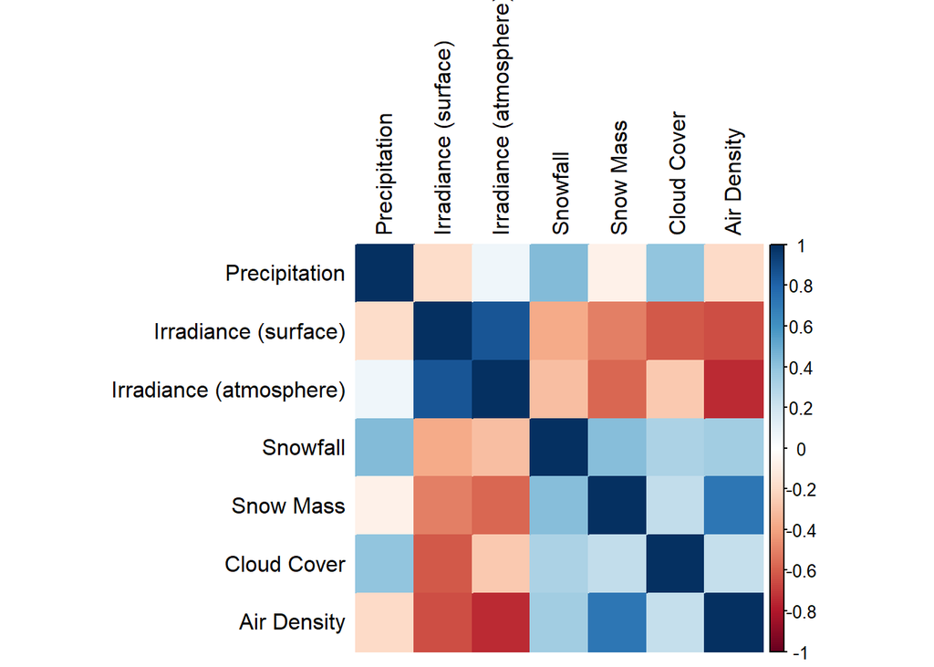

```r
library(corrplot)
# Plot the correlation matrix
corrplot(cor_matrix, method = "color", tl.col="black")
```

Thus, we may omit “IrradianceSurface” and “IrradianceToa” from future models for Temperature to avoid multicollinearity.

## Temperature forecasts

```r
## Training (75%) and testing (25%) datasets

Temp.Train <- Ontario.Daily %>% filter(Date <= "2019-06-30")
Temp.Test <- Ontario.Daily %>% filter(Date > "2019-06-30")
```

```r
library(fable.prophet)
```

```r
## Prophet Model (with covariates)
Prophet.Model.Temp2 <- Temp.Train %>%
  model(prophet(Temperature ~ Precipitation + Snowfall + SnowMass +
                  CloudCover + AirDensity))
fore.Prophet.Temp2 <- Prophet.Model.Temp2 %>% forecast(Temp.Test)
Prophet.Test.Accuracy2 <- fabletools::accuracy(fore.Prophet.Temp2, Temp.Test)
xtable(Prophet.Test.Accuracy2)
```

```
## % latex table generated in R 4.3.0 by xtable 1.8-4 package
## % Fri Feb  9 13:37:44 2024
## \begin{table}[ht]
## \centering
## \begin{tabular}{rllrrrrrrrr}
##   \hline
##  & .model & .type & ME & RMSE & MAE & MPE & MAPE & MASE & RMSSE & ACF1 \\
##   \hline
## 1 & prophet(Temperature \~{} Precipitation + Snowfall + SnowMass + CloudCover +
##     AirDensity) & Test & -3.14 & 5.23 & 4.03 & -321.97 & 593.19 &  &  & 0.97 \\
##    \hline
## \end{tabular}
## \end{table}
```

```r
## ARIMA Model (with covariates)
ARIMA.Model.Temp2 <- Temp.Train %>%
  model(ARIMA(Temperature ~ Precipitation + Snowfall + SnowMass + CloudCover + AirDensity))
ARIMA.Model.Temp2
```

```
## # A mable: 1 x 1
##   ARIMA(Temperature ~ Precipitation + Snowfall + SnowMass + CloudCover + \n   …¹
##                                                                          <model>
## 1                                          <LM w/ ARIMA(2,1,2)(2,0,0)[7] errors>
## # ℹ abbreviated name:
## #   ¹`ARIMA(Temperature ~ Precipitation + Snowfall + SnowMass + CloudCover + \n    AirDensity)`
```

```r
fore.ARIMA.Temp2 <- ARIMA.Model.Temp2 %>% forecast(Temp.Test)
ARIMA.Test.Accuracy2 <- fabletools::accuracy(fore.ARIMA.Temp2, Temp.Test)
xtable(ARIMA.Test.Accuracy2)
```

```
## % latex table generated in R 4.3.0 by xtable 1.8-4 package
## % Fri Feb  9 13:37:46 2024
## \begin{table}[ht]
## \centering
## \begin{tabular}{rllrrrrrrrr}
##   \hline
##  & .model & .type & ME & RMSE & MAE & MPE & MAPE & MASE & RMSSE & ACF1 \\
##   \hline
## 1 & ARIMA(Temperature \~{} Precipitation + Snowfall + SnowMass + CloudCover +
##     AirDensity) & Test & -2.42 & 4.30 & 3.30 & -231.77 & 453.35 &  &  & 0.97 \\
##    \hline
## \end{tabular}
## \end{table}
```

```r
## nnetar Model (with covariates)
nnetar.Model.Temp2 <- Temp.Train %>%
  model(NNETAR(Temperature ~ Precipitation + Snowfall + SnowMass + CloudCover + AirDensity))
nnetar.Model.Temp2
```

```
## # A mable: 1 x 1
##   NNETAR(Temperature ~ Precipitation + Snowfall + SnowMass + CloudCover + \n  …¹
##                                                                          <model>
## 1                                                             <NNAR(22,1,14)[7]>
## # ℹ abbreviated name:
## #   ¹`NNETAR(Temperature ~ Precipitation + Snowfall + SnowMass + CloudCover + \n    AirDensity)`
```

```r
fore.nnetar.Temp2 <- nnetar.Model.Temp2 %>% forecast(Temp.Test)
nnetar.Test.Accuracy2 <- fabletools::accuracy(fore.nnetar.Temp2, Temp.Test)
xtable(nnetar.Test.Accuracy2)
```

```
## % latex table generated in R 4.3.0 by xtable 1.8-4 package
## % Fri Feb  9 14:09:52 2024
## \begin{table}[ht]
## \centering
## \begin{tabular}{rllrrrrrrrr}
##   \hline
##  & .model & .type & ME & RMSE & MAE & MPE & MAPE & MASE & RMSSE & ACF1 \\
##   \hline
## 1 & NNETAR(Temperature \~{} Precipitation + Snowfall + SnowMass + CloudCover +
##     AirDensity) & Test & -0.28 & 1.27 & 1.03 & -37.54 & 80.83 &  &  & 0.63 \\
##    \hline
## \end{tabular}
## \end{table}
```

```r
## TSLM (with covariates)
TSLM.Model.Temp2 <- Temp.Train %>%
  model(TSLM(Temperature ~ Precipitation + Snowfall + SnowMass + CloudCover + AirDensity))
fore.TSLM.Temp2 <- TSLM.Model.Temp2 %>% forecast(Temp.Test)
TSLM.Temp.Accuracy2 <- fabletools::accuracy(fore.TSLM.Temp2, Temp.Test)
xtable(TSLM.Temp.Accuracy2)
```

```
## % latex table generated in R 4.3.0 by xtable 1.8-4 package
## % Fri Feb  9 14:09:53 2024
## \begin{table}[ht]
## \centering
## \begin{tabular}{rllrrrrrrrr}
##   \hline
##  & .model & .type & ME & RMSE & MAE & MPE & MAPE & MASE & RMSSE & ACF1 \\
##   \hline
## 1 & TSLM(Temperature \~{} Precipitation + Snowfall + SnowMass + CloudCover +
##     AirDensity) & Test & 0.14 & 1.68 & 1.34 & -19.39 & 69.26 &  &  & 0.72 \\
##    \hline
## \end{tabular}
## \end{table}
```